# Applied Machine Learning Project (Coursera)

Akijitsu

27 December 2015

## Introduction

This report is the required homework for the ‘Applied Machine Learning’ course by Johns Hopkins University on Coursera For full background to the exercise pelase see:

https://class.coursera.org/predmachlearn-035/human_grading

In brief this report examines ‘quantified self’ data from activity monitors (such as fitbit) and aims to build an accurate prediction model. The model will predict if a particular exercise has been performed correctly or not based on the data fed back from the device.

A quick look at the training data

```r
#str(pml_train)
#summary(pml_train)
```

## Data Cleaning and Pre Processing

Several columns have only NA values - remove these predictors from training set: Select only columns with more than 50% of values that are not NA

```r
new_train = pml_train[, colSums(is.na(pml_train)) <  nrow(pml_train) * 0.5]
```

We now have reduced set to 93 predictors. Let’s now remove predictors that have low variance using the nearZeroVar function

```r
low_variance = nearZeroVar(new_train)
if(length(low_variance) != 0) {
  new_train = new_train[, -low_variance]}
```

We now have reduced set to 59 variables

```r
str(new_train)
```

```
## 'data.frame':    19622 obs. of  59 variables:
##  $ X                   : int  1 2 3 4 5 6 7 8 9 10 ...
##  $ user_name           : Factor w/ 6 levels "adelmo","carlitos",..: 2 2 2 2 2 2 2 2 2 2 ...
##  $ raw_timestamp_part_1: int  1323084231 1323084231 1323084231 1323084232 1323084232 1323084232 1323084232 1323084232 1323084232 1323084232 ...
##  $ raw_timestamp_part_2: int  788290 808298 820366 120339 196328 304277 368296 440390 484323 484434 ...
##  $ cvtd_timestamp      : Factor w/ 20 levels "02/12/2011 13:32",..: 9 9 9 9 9 9 9 9 9 9 ...
##  $ num_window          : int  11 11 11 12 12 12 12 12 12 12 ...
##  $ roll_belt           : num  1.41 1.41 1.42 1.48 1.48 1.45 1.42 1.42 1.43 1.45 ...
##  $ pitch_belt          : num  8.07 8.07 8.07 8.05 8.07 8.06 8.09 8.13 8.16 8.17 ...
##  $ yaw_belt            : num  -94.4 -94.4 -94.4 -94.4 -94.4 -94.4 -94.4 -94.4 -94.4 -94.4 ...
##  $ total_accel_belt    : int  3 3 3 3 3 3 3 3 3 3 ...
##  $ gyros_belt_x        : num  0 0.02 0 0.02 0.02 0.02 0.02 0.02 0.02 0.03 ...
##  $ gyros_belt_y        : num  0 0 0 0 0.02 0 0 0 0 0 ...
##  $ gyros_belt_z        : num  -0.02 -0.02 -0.02 -0.03 -0.02 -0.02 -0.02 -0.02 -0.02 0 ...
##  $ accel_belt_x        : int  -21 -22 -20 -22 -21 -21 -22 -22 -20 -21 ...
```

[output cut: 45 more lines]

Remove row name variable X and Timestamp variable

```r
new_train = new_train %>% select(-X)
# We now have reduced set to 58 variables (including target variabe classe)

# remove cvtd_timestamp - causing problems at submission stage
new_train = new_train %>% select(-cvtd_timestamp)
```

## Split new_train into train and test sets

I will use a random 70:30 split - note the target variable is ‘classe’

```r
library(caTools)
set.seed(100)
split = sample.split(new_train$classe, SplitRatio = 0.7)
Train = subset(new_train, split==TRUE)
Test = subset(new_train, split==FALSE)
```

## CART (Classification & Regrression Trees) Model

Install rpart library to build CART (Classification & Regrression Tree )

```r
#install.packages("rpart")
library(rpart)
#install.packages("rpart.plot")
library(rpart.plot)
```

### CART model

Minbucket selection is a tuning parameter for the model. It defines the minimum number of observations in each node.

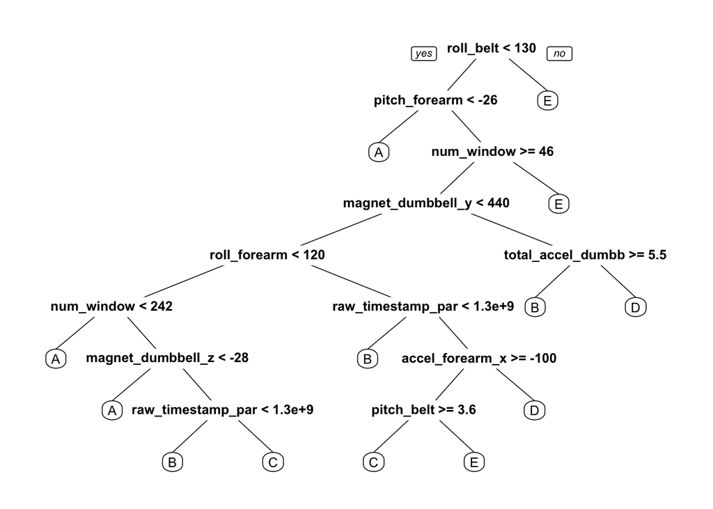

```r
cart_tree = rpart(classe ~. , method="class", data = Train, control=rpart.control(minbucket=500))
prp(cart_tree)
```

The CART model has several splits and may not be easily interpretable. However it may still have good predictive power. Let’s test the model and see how good its predictive power is.